# Praca Zaliczeniowa z przedmiotu *Credit Scoring w R* Regresja logistczna vs. XGBoost na danych German Credit Data

Mateusz Jastrząb Hubert Ratajczyk

24 stycznia 2018

### Wstęp

W poniższej pracy porównane są dwie metody modelowania ryzyka kredytowego. Klasyczna regresja logistyczna będąca obecnie standardem rynkowym i machine learningowe podejście wykorzystujące algorytm XGBoost. Porówanie jest przeprowadzone na zbiorze German Credit Data. W obu podejściach przekształcamy zmienne zgodnie z metodologią *WoE*. Uzyskane na potrzeby obu modeli grupowania zmiennych różnią się. Oba modele zsotały oszcowane na takiej samej próbie trenującej i zwalidowane na takiej samej próbie walidującej.

### Dane

Zbiór German Credit Data zawiera 1000 obserwacji dotyczących przebiegu udzielonych kredytów. W danych znajdziemy 700 obserwacji zakończonych spłatą zobowiązania i 300 zakończonych *defaultem*. Zbiór pochodzi z 1994 roku i zawiera 20 zmiennych zarówno ciagłych jak i dyskretnych.

## Charakterystyki zmiennych

Poniżej prezentujemy histogramy wybranych zmiennych które znalazły się ostatecznie w modelu regresji logsitycznej(więcej w skrypcie).

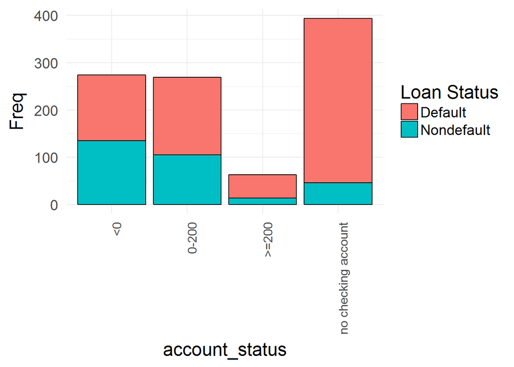

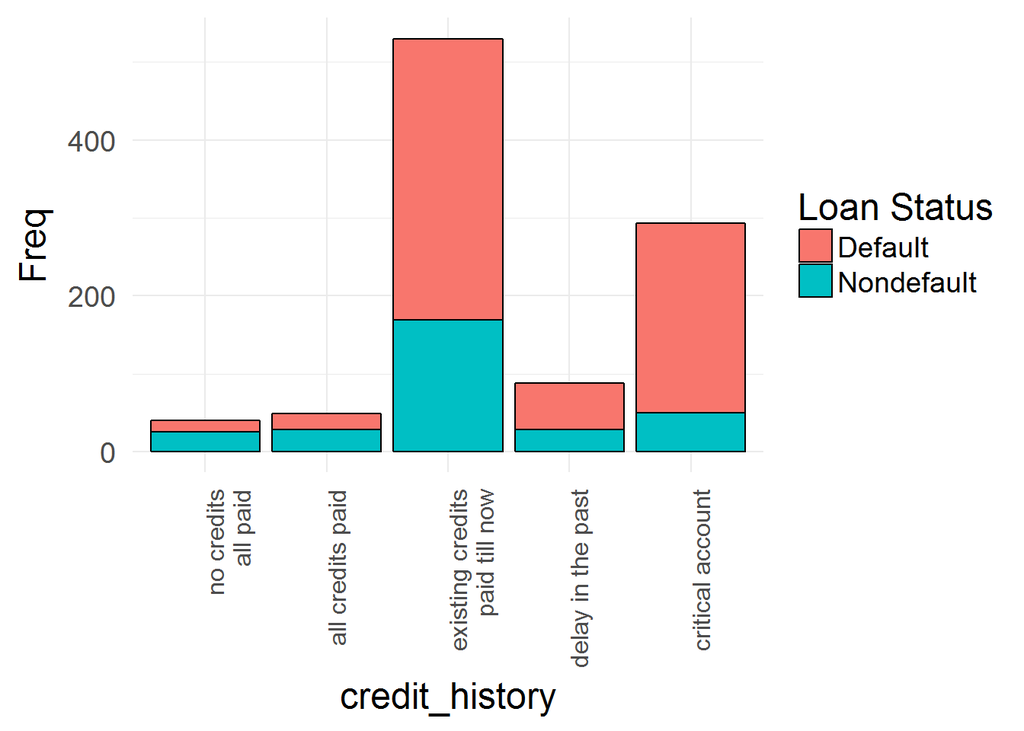

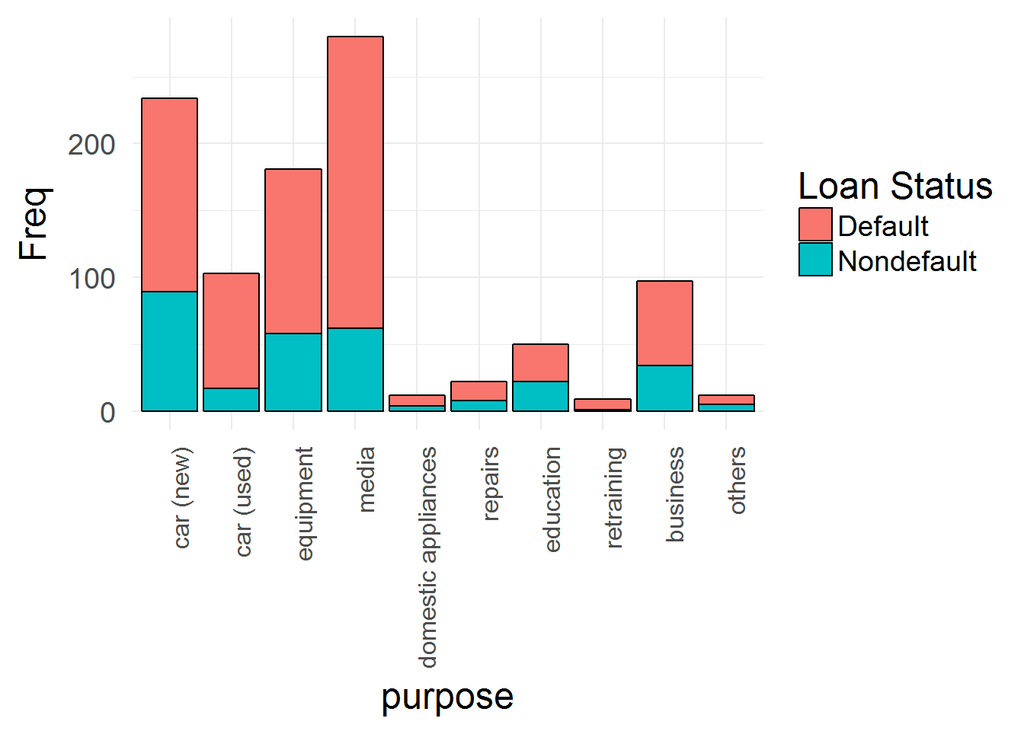

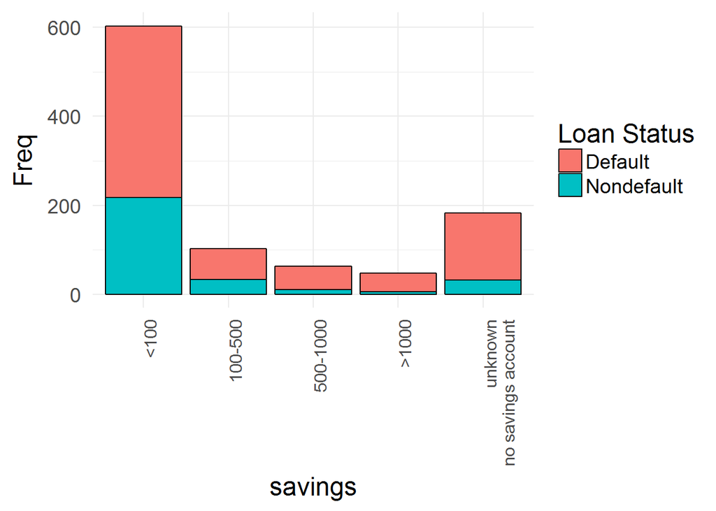

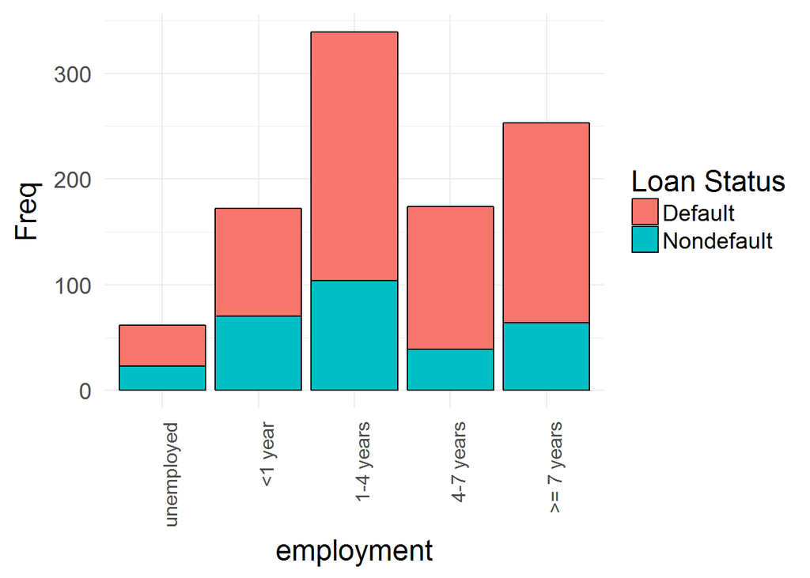

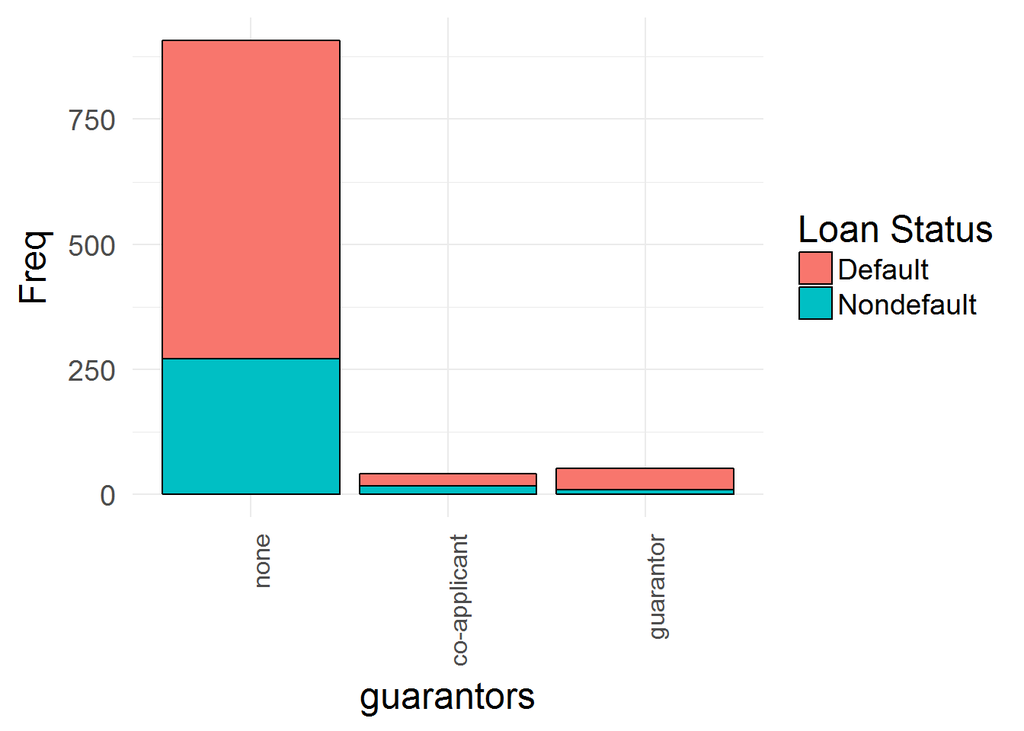

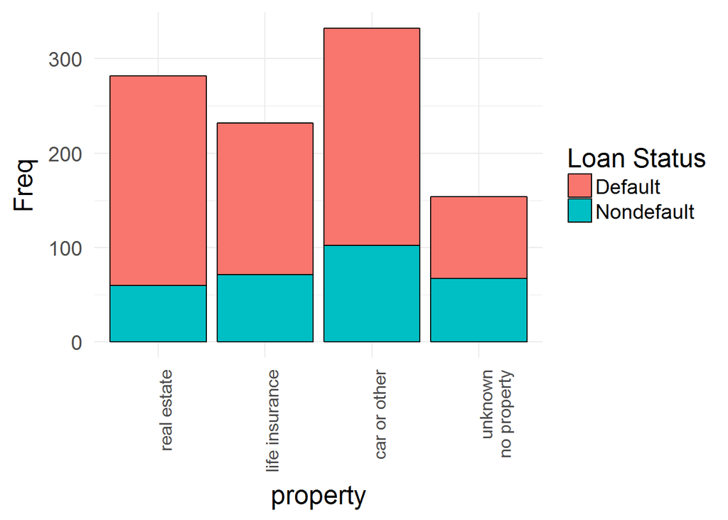

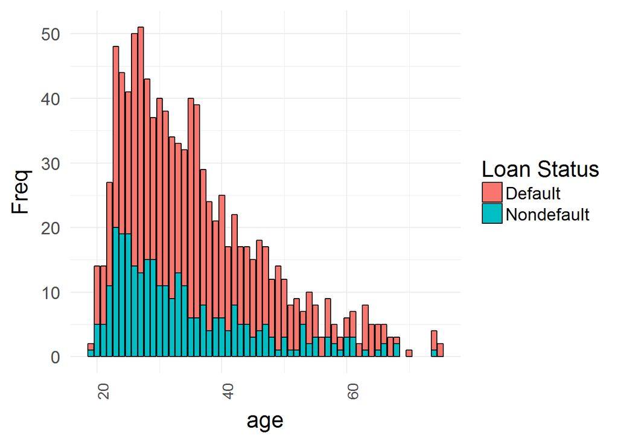

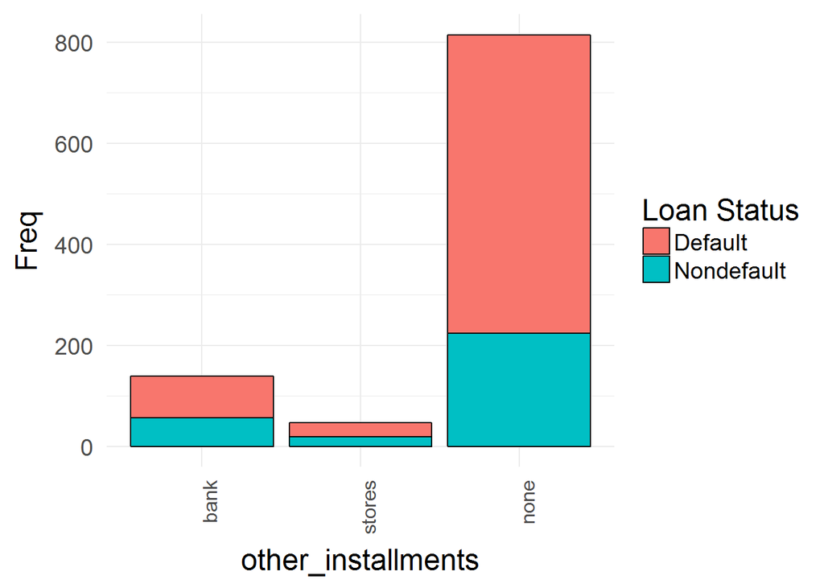

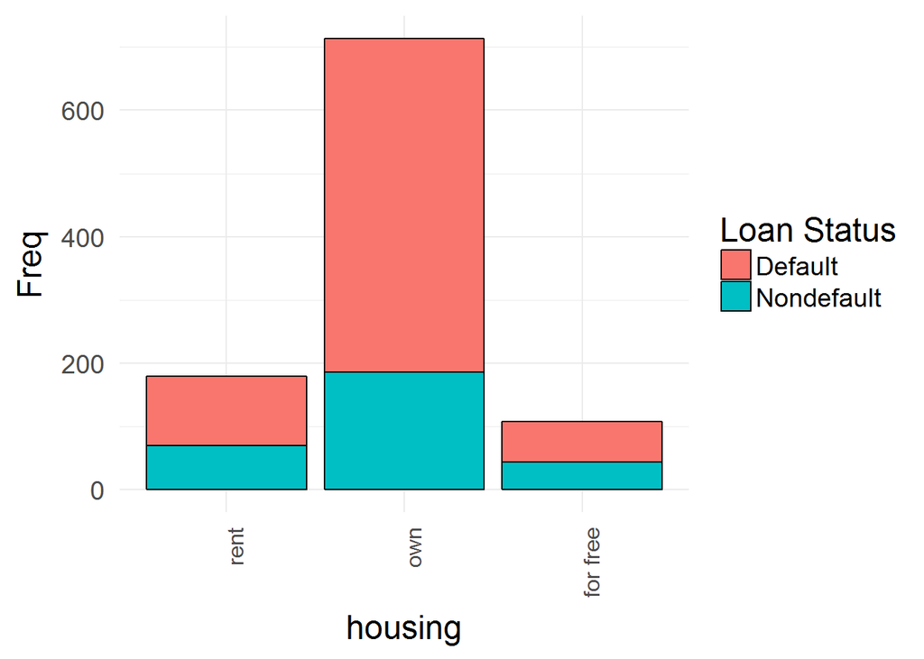

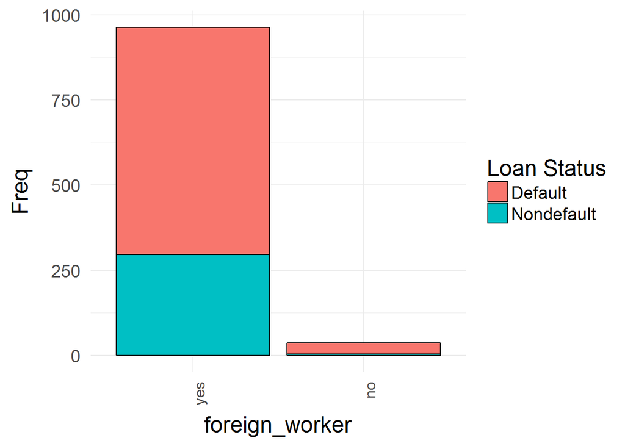

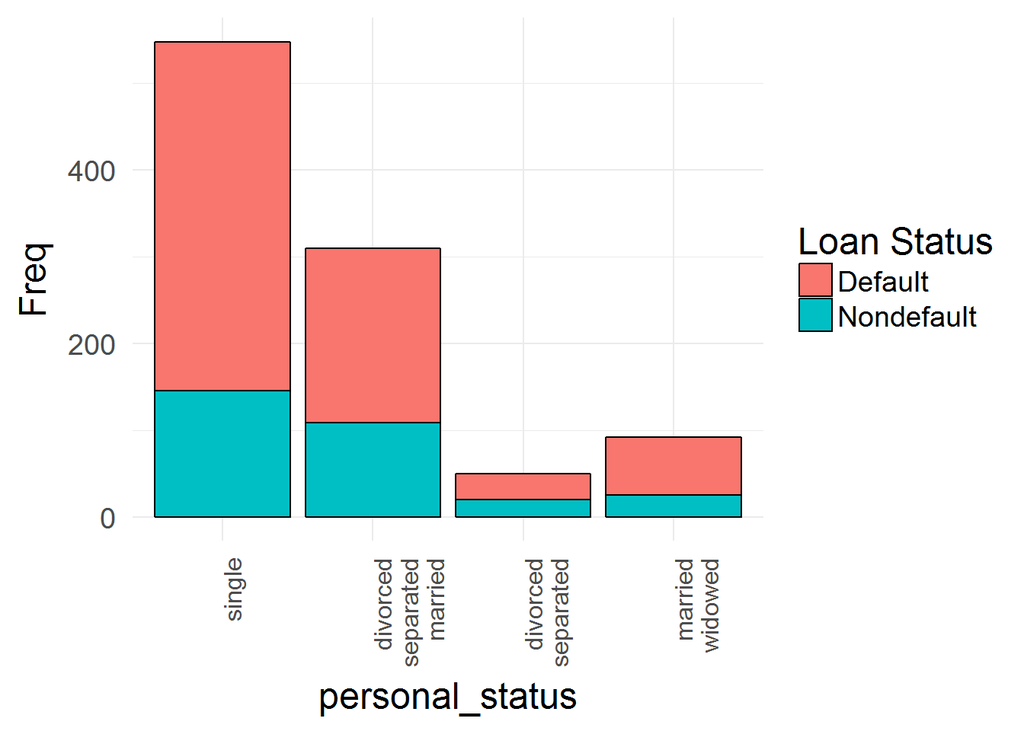

Poniżej prezentujemy wyniki testu Chi-Squared dla zmiennych kategorycznych względem zmiennej objaśnianej *defaulted*.

```
##              Variable Test_statistic p_value cramers_v  Dependency
## 1      account_status       123.7209       0    0.3517   Dependent
## 2      credit_history        61.6914       0    0.2484   Dependent
## 3             purpose        33.3564  0.0001    0.1826   Dependent
## 4             savings        36.0989       0      0.19   Dependent
## 5          employment        18.3683   0.001    0.1355   Dependent
## 6    installment_rate         5.4768    0.14     0.074 Independent
## 7     personal_status         9.6052  0.0222     0.098   Dependent
## 8          guarantors         6.6454  0.0361    0.0815   Dependent
## 9           residence         0.7493  0.8616    0.0274 Independent
## 10           property        23.7196       0     0.154   Dependent
## 11 other_installments        12.8392  0.0016    0.1133   Dependent
## 12            housing        18.1998  0.0001    0.1349   Dependent
## 13       credit_cards         2.6712  0.4451    0.0517 Independent
## 14                job         1.8852  0.5966    0.0434 Independent
## 15         dependents         0.0091   0.924     0.003 Independent
## 16              phone         1.3298  0.2488    0.0365 Independent
## 17     foreign_worker          6.737  0.0094    0.0821   Dependent
## 18                sex         5.6991   0.017    0.0755   Dependent
```

Dla zmiennych ciągłych liczymy współczynnik korelacji Kendalla. Macierz korelacji zwiera także nowo stworzone zmienne taki jak Income i Installment(def. w skrypcie).

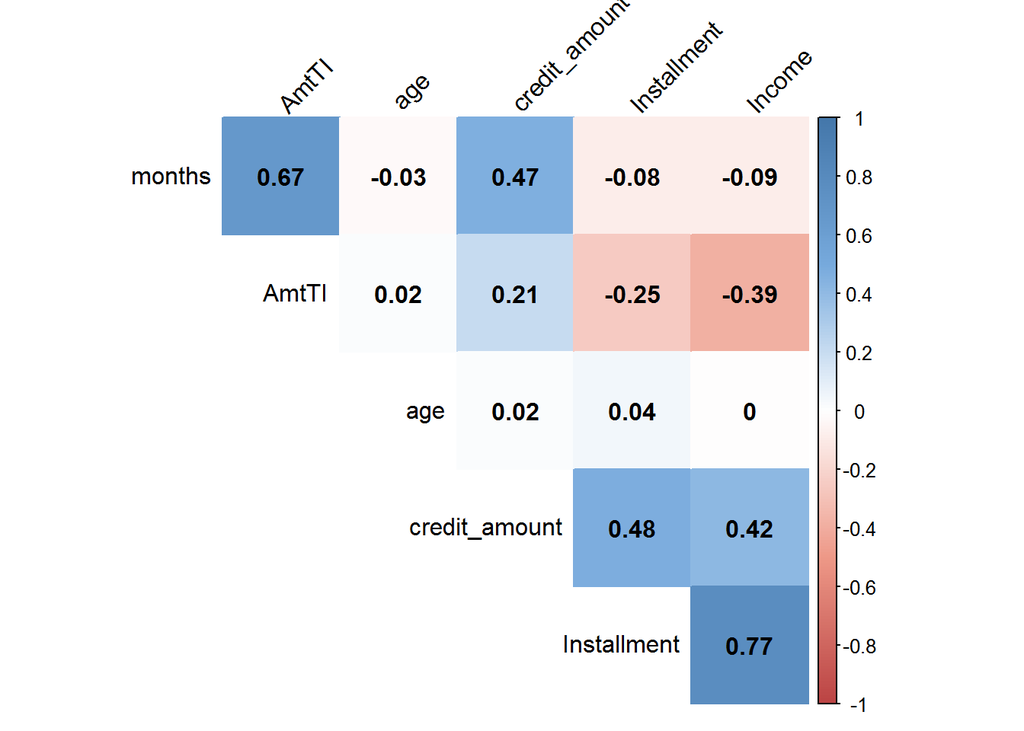

## Regresja Logistyczna - Grupowanie zmiennych według metodologii *WoE*

Na wykresach poniżej prezentujemy grupowanie zmiennych dykretnych i cigałych w za poomocą metodologii *WoE*.

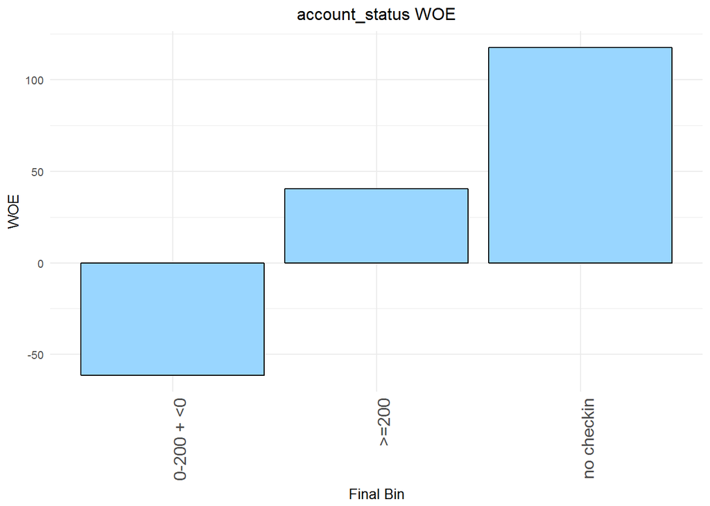

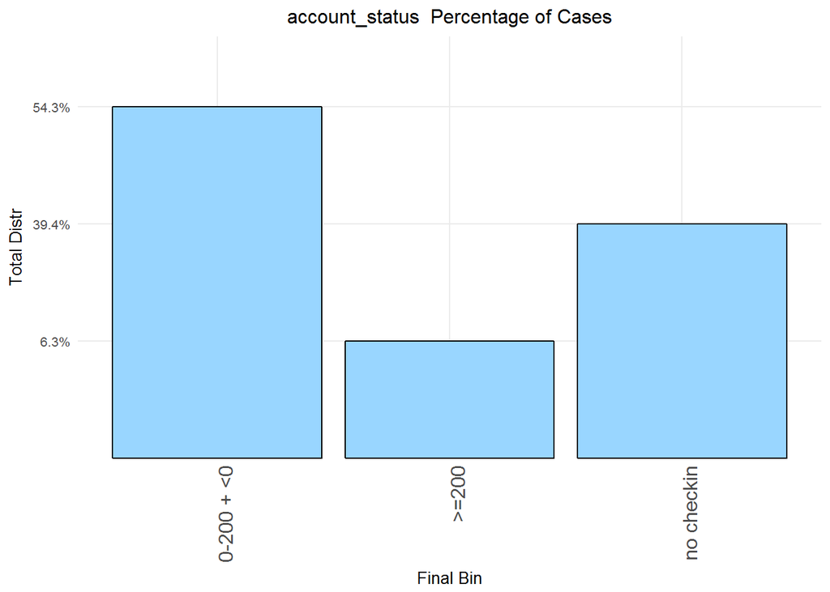

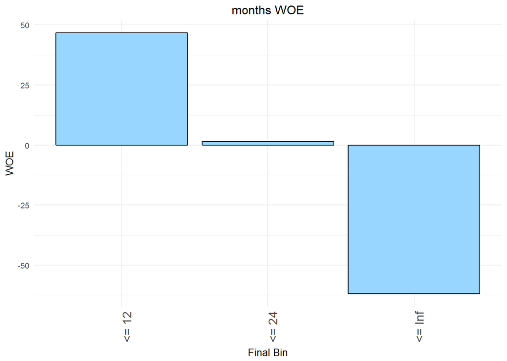

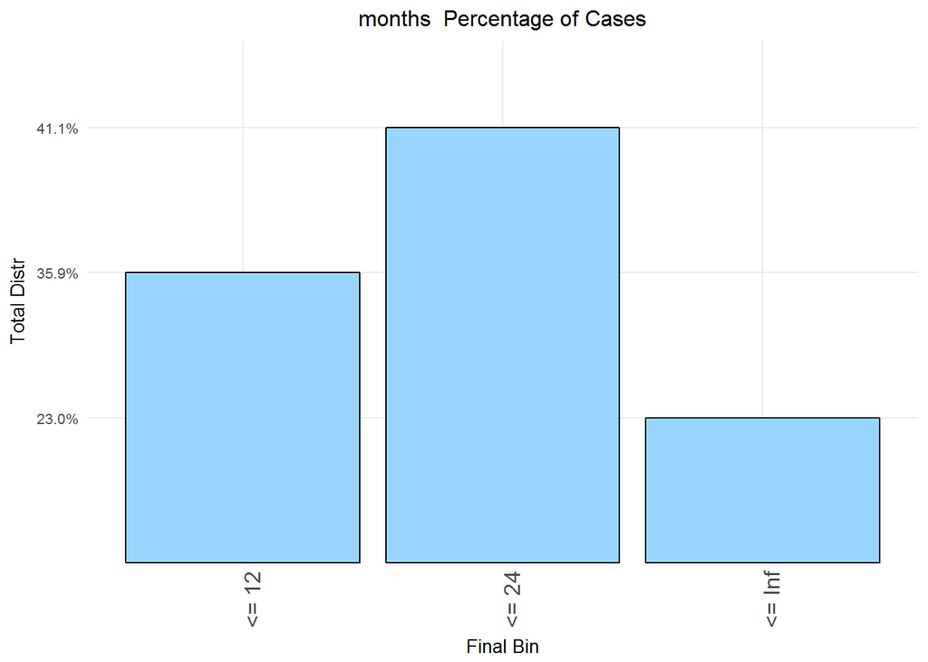

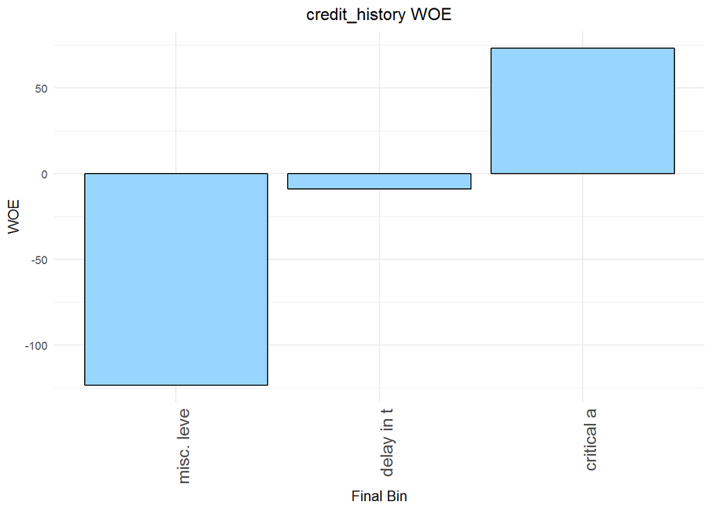

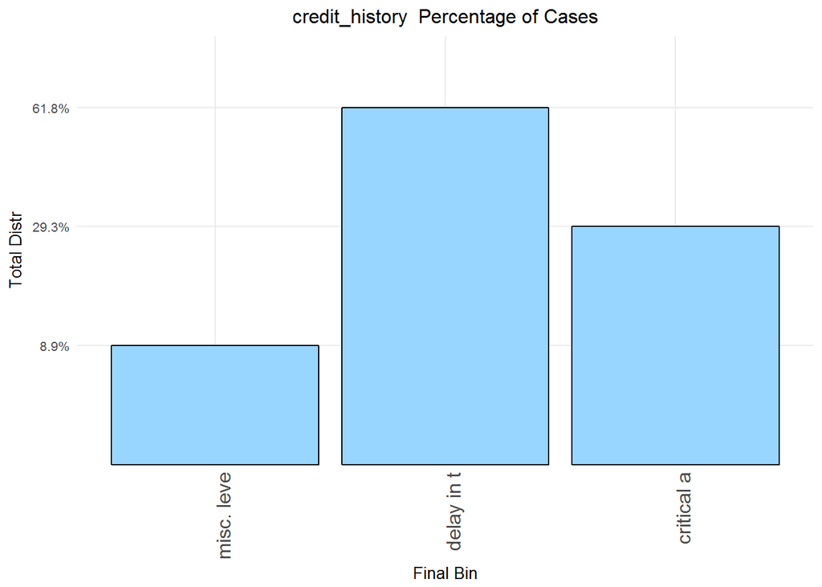

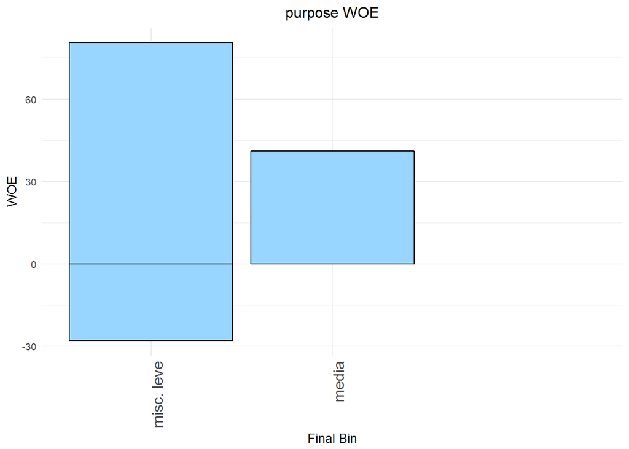

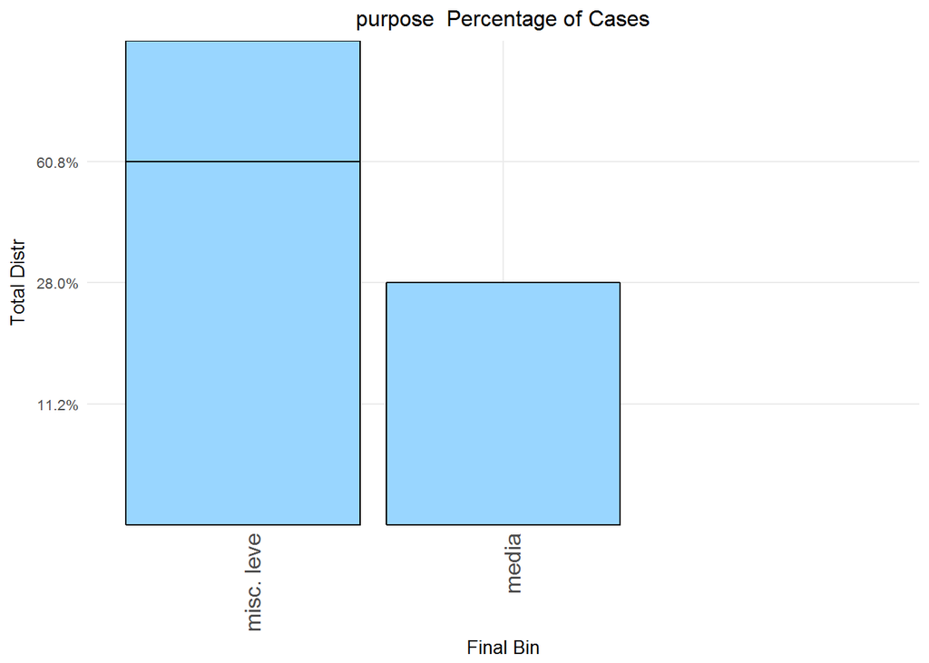

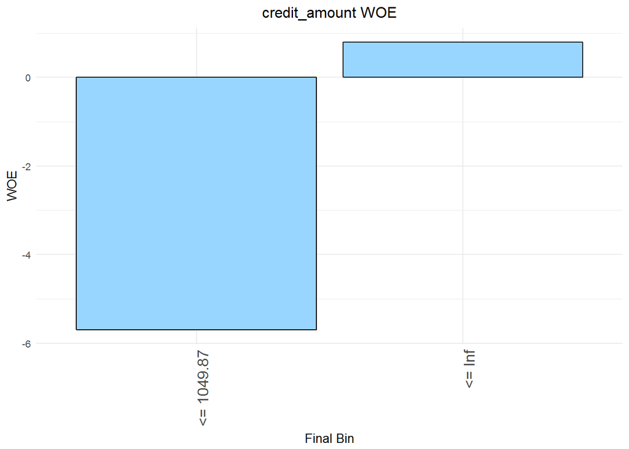

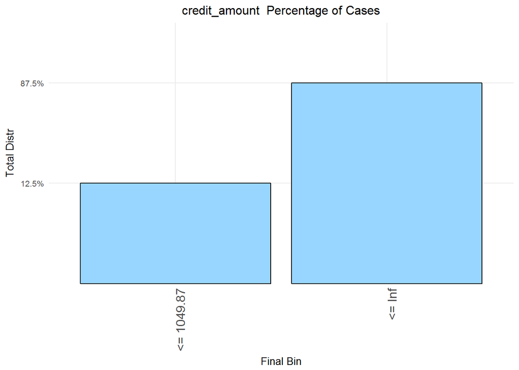

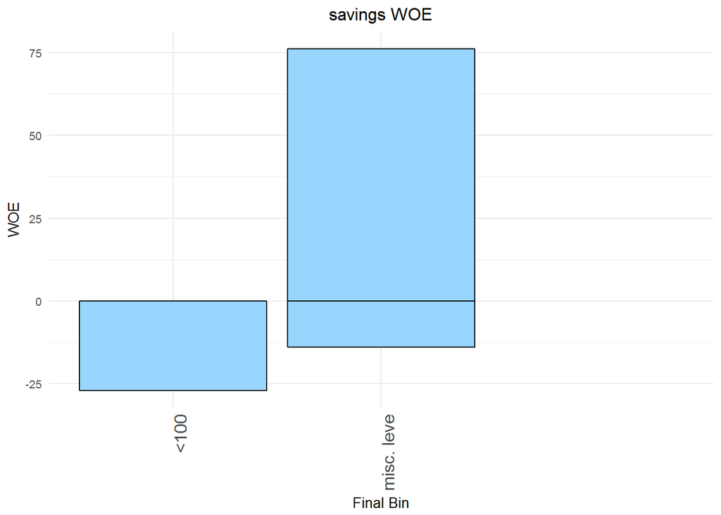

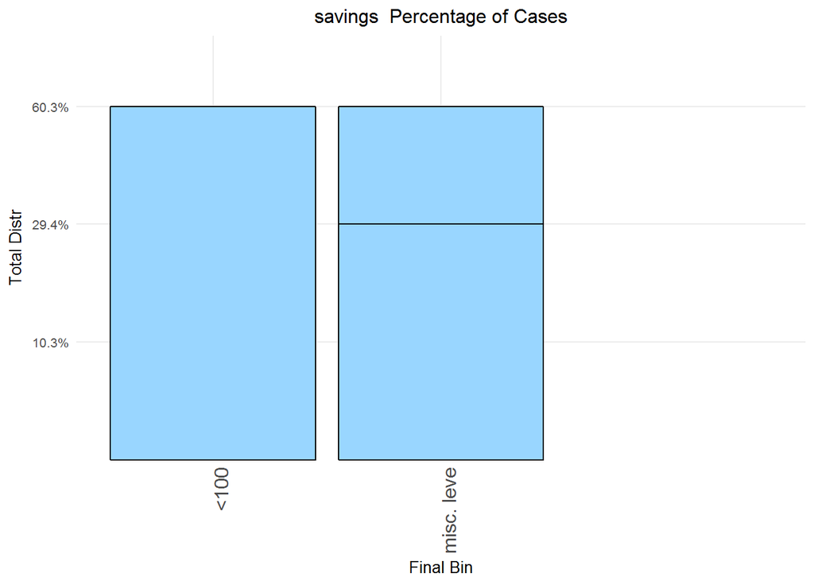

[36 more figures not shown]

## Regresja Logistyczna - Information Value

Poniżej prezentujemy Information Value dla zmiennych w naszy zbiorze.

```
##              Variable    IV
## 1      account_status 0.639
## 2      credit_history 0.292
## 3               AmtTI 0.216
## 4             savings 0.191
## 5              months 0.168
## 6             purpose 0.153
## 7            property 0.113
## 8                 age 0.093
## 9          employment 0.086
## 10            housing 0.083
## 11 other_installments 0.058
## 12    personal_status 0.045
## 13     foreign_worker 0.044
## 14         guarantors 0.032
## 15                sex 0.027
## 16   installment_rate 0.026
## 17             Income 0.024
## 18        Installment 0.016
## 19       credit_cards 0.013
## 20                job 0.008
## 21              phone 0.006
## 22          residence 0.003
## 23      credit_amount 0.000
## 24         dependents 0.000
```

## Regresja Logistyczna - Podział na próbę testową i walidacyjną

Dokonujemy podziału na próbę testową i walidacyjną w proporcji 70%/30%. Przeprowadzamy losowanie ze stratyfikacją względem zmiennej objaśnianej aby w obu próbach otrzymac zblizony poziom *default rate*. Podziału dokonujemy za pomocą fukncji *createDataPartition*(więcej szczegółów dot. podziału w skrypcie).

## Regresja Logistyczna - Estymacja modelu

```
##
## Call:  glm(formula = defaulted ~ account_status + credit_history + purpose +
##     savings + employment + guarantors + residence + property +
##     age + other_installments + housing + credit_cards + foreign_worker +
##     Income + AmtTI + personal_status, family = binomial("logit"),
##     data = Model.DF.train)
##
## Coefficients:
##        (Intercept)      account_status      credit_history
##          -0.939232           -0.008116           -0.008372
##            purpose             savings          employment
##          -0.010016           -0.008214           -0.006695
##         guarantors           residence            property
##          -0.010652           -0.029706           -0.006476
##                age  other_installments             housing
##          -0.008972           -0.009491           -0.006504
##       credit_cards      foreign_worker              Income
##           0.014067           -0.011978           -0.017411
##              AmtTI     personal_status
##          -0.010349           -0.010313
##
## Degrees of Freedom: 699 Total (i.e. Null);  683 Residual
## Null Deviance:       846.6
## Residual Deviance: 623.4     AIC: 657.4
```

W kolejnych krokach wykorzystując w pewnym sensie schemat postępowania *od ogółu do szczegółu*(zaa pomocą *LR test*), sprawdzamy czy możmy usunąć z modelu zmienne które nie są istotne na 5% poziomie istotności. W ten sposób usuwamy dwie zmienne *credit_cards* i *residence*.

```
##
## Call:
## glm(formula = defaulted ~ account_status + credit_history + purpose +
##     savings + employment + guarantors + property + age + other_installments +
##     housing + foreign_worker + Income + AmtTI + personal_status,
##     family = binomial("logit"), data = Model.DF.train)
##
## Deviance Residuals:
##     Min       1Q   Median       3Q      Max
## -2.1429  -0.7179  -0.3682   0.7345   2.5398
##
## Coefficients:
##                     Estimate Std. Error z value Pr(>|z|)
## (Intercept)        -0.940125   0.103996  -9.040  < 2e-16 ***
## account_status     -0.007693   0.001339  -5.744 9.25e-09 ***
## credit_history     -0.007569   0.001926  -3.930 8.49e-05 ***
## purpose            -0.009927   0.002677  -3.708 0.000209 ***
## savings            -0.008020   0.002497  -3.212 0.001317 **
## employment         -0.006410   0.003416  -1.876 0.060605 .
## guarantors         -0.010101   0.005274  -1.915 0.055456 .
## property           -0.005914   0.003476  -1.701 0.088887 .
## age                -0.008099   0.003367  -2.406 0.016144 *
## other_installments -0.010265   0.004035  -2.544 0.010961 *
## housing            -0.007231   0.003712  -1.948 0.051408 .
## foreign_worker     -0.011610   0.006492  -1.788 0.073735 .
## Income             -0.015579   0.006325  -2.463 0.013782 *
## AmtTI              -0.010614   0.002478  -4.283 1.85e-05 ***
## personal_status    -0.009412   0.004875  -1.931 0.053517 .
## ---
## Signif. codes:  0 '***' 0.001 '**' 0.01 '*' 0.05 '.' 0.1 ' ' 1
##
## (Dispersion parameter for binomial family taken to be 1)
##
##     Null deviance: 846.57  on 699  degrees of freedom
## Residual deviance: 628.79  on 685  degrees of freedom
## AIC: 658.79
##
## Number of Fisher Scoring iterations: 5
```

## Regresja Logistyczna - Testy jakości dopasowania

Poniżej prezentujemy wyniki testu Hosmera - Lemeshowa dla 3 różnych ilości przedziałów. Odpowiednio dla 10, 9 i 8 przedziałów. Każdy z tych testów wskazuje że nie mamy podstaw do odrzuecnia Hipotezy zerowej do ddobrym dopasowaniu modelu do danych.

|  | Wartość Statystyki | P - Wartość |
| --- | --- | --- |
| H-L(10) | 9.624297 | 0.2923913 |
| H-L(9) | 4.790311 | 0.6855349 |
| H-L(8) | 5.673424 | 0.4607487 |

Prezentujemy także tabelke z pakietu *LogisticDx* która w dogodny sposób przedstawia wyniki testów na jakość dopasowania dla regresji logistycznej.

```
##       chiSq  df    pVal
## PrI  646.86 685 0.84898
## drI  628.79 685 0.93871
## PrG  612.58 641 0.78442
## drG  603.84 641 0.85081
## PrCT 612.58 641 0.78442
## drCT 603.84 641 0.85081
##                      val df     pVal
## HL chiSq         9.52768  8 0.299752
## mHL F            1.89317  9 0.050168 .
## OsRo Z                NA NA 0.600199
## SstPgeq0.5 Z     0.65905 NA 0.509862
## SstPl0.5 Z       1.06325 NA 0.287669
## SstBoth chiSq    1.56485  2 0.457295
## SllPgeq0.5 chiSq 0.41088  1 0.521525
## SllPl0.5 chiSq   1.23320  1 0.266786
## SllBoth chiSq    1.23362  2 0.539662
## ---
## Signif. codes:  0 '***' 0.001 '**' 0.01 '*' 0.05 '.' 0.1 ' ' 1
```

## Regresja Logistyczna - Rozkład oszacowanych prawdopodobieństw *defaultu*

Przeprowadzamy test ROC w wyniku którego stwierdzamy że mamy podstawy do odrzucei hipotezy zerowej że krzywa ROC w modelu docelowym jest istotnie różna od krzywej ROC dla modelu bazowego(tylko stała, więcej w skrypcie). Wartość współczynnika Giniiego dla naszego modelu na próbie testwoej wynosi 66% (p.uf. 59% - 72% ) natomiast na próbie walidacyjnej 57% (p.uf. 46% - 68%). Ze względu na małą liczbę osberwacji przedziały ufności dla wpółczynnika Gini są bardzo szerokie. Za pomocą testu Kołomogorowa - Smironova testujemy czy rozkłady *scorea* różnią się dla dobrych i złych klientów. Zarówno dla próby testowej jak i walidacyjnej mamy silne podstawy do odrzucenia hipotezy zeroewej że wspomniane rozkłqdy są zbliżone do siebie(więcej w skyrpcie).

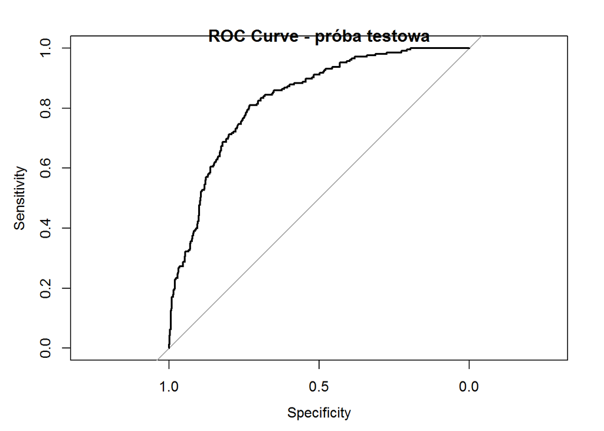

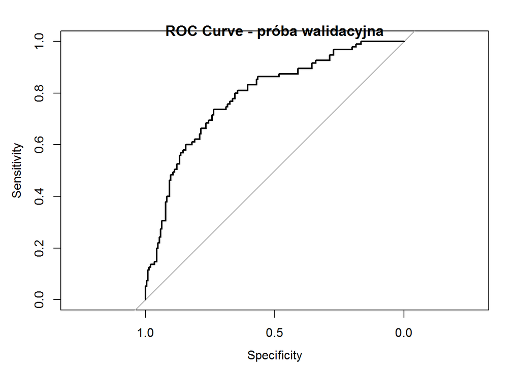

## Regresja Logistyczna - Stabilność modelu

Aby zweryfikować stabliność modelu wyliczamy Population Stability Index dla rozkładu *scorów* w próbie walidacyjnej i testowej. Sprawdzamy także za pomocą testu Kołomogorowa Smirnova podobieństwo rozkładu *scorów* dla próby testowej i walidacyjnej. Upewniamy się także czy nie występują zbbyt czesto identyczne wartości *scorea*.

## Regresja Logistyczna - Ocena modelu i poszczególnych zmiennych

Przygotowujemy zgodnie najważniejszych charkterystyk modelu(załącznik “ocena_modelu”). Przygotoujemy także najważniejsze charkterystyki opisujące wpływ każdej ze (załącznik “ocena_zmienne”).

## Regresja Logistyczna - Karta scoringowa

Zgodnie z zaleceniami wyniki modelu zostały przeskalowane do scorea w taki sposób że *score_points*=660, *log_odds*=1/72, *ptd*=40. Karta scoringowa znajduje się w załączniku “karta_scoringowa.csv”.

## Regresja Logistyczna - Kalibracja

Dokonujemy kalbracji karty poprzez regresję zmiennej *defaulted* na *score* i stałą. W dalszej kolejności odpowidnio skalibrowany wynik dzielimy na grupy ryzyka.

```
##
## Call:
## glm(formula = defaulted ~ score_mod, family = binomial("logit"),
##     data = Model.DF.train)
##
## Deviance Residuals:
##     Min       1Q   Median       3Q      Max
## -2.1429  -0.7179  -0.3682   0.7345   2.5398
##
## Coefficients:
##              Estimate Std. Error z value Pr(>|z|)
## (Intercept)  7.160262   0.671699   10.66   <2e-16 ***
## score_mod   -0.017329   0.001485  -11.67   <2e-16 ***
## ---
## Signif. codes:  0 '***' 0.001 '**' 0.01 '*' 0.05 '.' 0.1 ' ' 1
##
## (Dispersion parameter for binomial family taken to be 1)
##
##     Null deviance: 846.57  on 699  degrees of freedom
## Residual deviance: 628.79  on 698  degrees of freedom
## AIC: 632.79
##
## Number of Fisher Scoring iterations: 5
```

## Regresja Logistyczna - Wybór punktu odcięcia

W ostatnim kroku zastanawiamy się nad wyborem punktu odcięcia. Najrosądniejsze z punktu widzenia autorów wskazanie punktu odcięcia(466.2755540) otrzymujemy z kryterium *Youden*-a. Wybierająć ten punkt odcięcia godzimy się na to że wpuścimy do portfela 39 złych klientów i odmówimy niesłusznie 133 dobrym klientom.

```
##
## Call:
## optimal.cutpoints.formula(X = score ~ defaulted, tag.healthy = 0,
##     methods = c("Youden"), data = Model.DF.train, direction = ">",
##     control = control.cutpoints(costs.ratio = cr), ci.fit = TRUE,
##     trace = T)
##
## Area under the ROC curve (AUC):  0.83 (0.799, 0.862)
##
## CRITERION: Youden
## Number of optimal cutoffs: 1
##
##                      Estimate 95% CI lower limit 95% CI upper limit
## cutoff            466.2755540                  -                  -
## Se                  0.8097561          0.7492380          0.8610816
## Sp                  0.7313131          0.6899463          0.7698917
## PPV                 0.5551839          0.5050528          0.6450875
## NPV                 0.9027431          0.8669445          0.9194196
## DLR.Positive        3.0137539          2.5687531          3.5358449
## DLR.Negative        0.2601401          0.1951559          0.3467633
## FP                133.0000000                  -                  -
## FN                 39.0000000                  -                  -
## Optimal criterion   0.5410692                  -                  -
```

### XGBoost

Przed zdefiniowaniem właściwego modelu **XGBoost**, należy spojrzeć najpierw na hasło **Boosting**. Idea procesu, jakim jest boosting powstała z potrzeby poprawiania jakości dopasowań *weak learnera* i opiera się na filtrowaniu obserwacji. *Weak learner* jest to prosty klasyfikator, który zazwyczaj radzi sobie nieco lepiej powyżej stanu losowego. Filtrowanie odbywa się w taki sposób, aby *weak learner* dostał część zbioru danych, z którymi może sobie bezproblemowo poradzić. Natomiast do pozostałych, czyli sprawiających trudność dopasowywane są kolejne jednostki *weak learnerów*.

Pierwszym algorytmem wykorzystującym boosting z powodzeniem, był **Adaptive Boosting** lub **AdaBoost**. Tam *weak learnerzy* to drzewa decyzyjne, z pojedynczym podziałem, nazywane *decision stumps*. AdaBoost realizuje klasyfikację poprzez przypisywanie różnych wag poszczególnym obserwacjom, kładąc większy nacisk na trudne do sklasyfikowania jednostki. Kolejne drzewa decyzyjne są dodawane sekwencyjnie i skupiają się na coraz bardziej zaawansowanych wzorcach. Predykcje tworzą się poprzez głosowanie większościowe *weak learnerów*, ważone ich indywidualną dokładnością lub *accuracy*.

Podobnym algorytmem jest **Stochastic Gradient Boosting**, gdzie w dużym uproszczeniu można przyjąć, że kolejne wagi dla *weak learnerów* są definiowane przez gradient. Nawiązując do twórcy algorytmu **XGBoost**, jego dzieło jaki i bliski krewny SGB opierają się na metodzie **gradient boosting**. Należy tutaj zauważyć, że zwykły SGB ma silną tendencję do przeuczania się, dlatego w XGBoost został dodany bardziej zregularyzowany model, aby lepiej kontrolować przeuczanie.

Do trenowania i tuningowania algorytmu użyliśmy biblioteki caret. Implementując XGBoost można ustalić następujące parametry:

- nrounds - liczba iteracji, które model wykona zanim się zatrzyma,
- max_dept - maksymalna głębokość pojedynczego drzewa,
- eta - *learning rate*, czyli stopa kurczenia się wag dla zmiennych.
- gamma - minimalna redukcja straty,
- colsample_bytree - losowo wybierana ilość zmiennych, spośród wszystkich zmiennych w macierzy wejściowej,
- min_child_weight - minimalna suma wag w węźle,
- subsample - odsetek danych pobieranych do hodowania drzew decyzyjnych,

oraz wiele innych, których lista dostępna jest pod adresem https://github.com/dmlc/xgboost/blob/master/doc/parameter.md, ale my skupimy się na powyższych 7.

Tuningowanie parametrów w XGBoost jest dość czasochłonnym procesem. Szczególnie, jeżeli przyjmujemy metodę *grid search*. Wtedy, mając do wyboru 7 parametrów i przeszukując tylko po 3 wartości z każdego, daje to $3^7$ modeli do kroswalidacji. W związku z tym, najpierw użyliśmy metody bayesowskiej optymalizacji (znacznie szybciej), której implementacja widoczna jest poniżej.

```r
require(rBayesianOptimization)
require(xgboost)

train.label = Model.DF.train$defaulted
new_tr <- model.matrix(~.+0,data = Model.DF.train[,-which(colnames(Model.DF.train) == "defaulted")])

dtrain <- xgb.DMatrix(new_tr,
                      label = train.label)


cv_folds <- KFold(train.label, nfolds = 10,
                  stratified = TRUE, seed = 2017)

xgb_cv_bayes <- function(max.depth, min_child_weight, subsample, eta, gamma, colsample_bytree, nrounds) {
  cv <- xgb.cv(params = list(booster = "gbtree",
                             eta = eta,
                             max_depth = max.depth,
                             min_child_weight = min_child_weight,
                             subsample = subsample, colsample_bytree = colsample_bytree,
                             gamma = gamma,
                             lambda = 1, alpha = 0,
                             objective = "binary:logistic",
                             eval_metric = "auc"),
               data = dtrain, nround = 100,
               folds = cv_folds, prediction = TRUE, showsd = TRUE,
               early_stopping_rounds = 25, maximize = TRUE, verbose = 0)
  list(Score = cv$evaluation_log[, max(test_auc_mean)],
       Pred = cv$pred)
}

OPT_Res <- BayesianOptimization(xgb_cv_bayes,bounds = list(max.depth = c(3:12),
                                                           min_child_weight = c(0.5, 1, 2,5),
                                                           subsample = c(0.5, 0.8),
                                                           eta = c(0.01,0.1,0.3),
                                                           gamma = c(0.1,1, 2,5),
                                                           colsample_bytree = c(0.4, 0.7, 1.0)
),
init_grid_dt = NULL, init_points = 10, n_iter = 40,
acq = "ucb", kappa = 2.576, eps = 0.0,
verbose = TRUE)
```

Otrzymane parametry zaimplementowaliśmy w funkcji z pakietu caret używając 5-krotnie powtarzanej 10-krotnej kroswalidacji.

Ponieważ jest to algorytm oparty na drzewach decyzyjnych, możliwe jest uzyskanie wykresu *ważności zmiennych*, czyli ustalonej przez model hierarchii zmiennych wykorzystanych do predykcji.

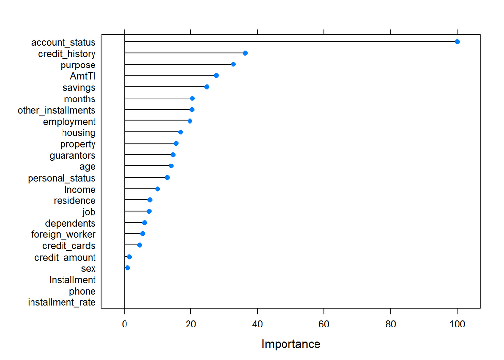

Pamiętając wartości Information Value dla poszczególnych zmiennych, wcale nie dziwi czołowa pozycja account_status (IV = 0.639), credit_history (0.292), ale zadziwiające może być purpose, sklasyfikowane przez nas na podstawie IV raczej w środku stawki (0.15). Być może model dzięki tej zmiennej uzyskał sensowne i ważne interakcje.

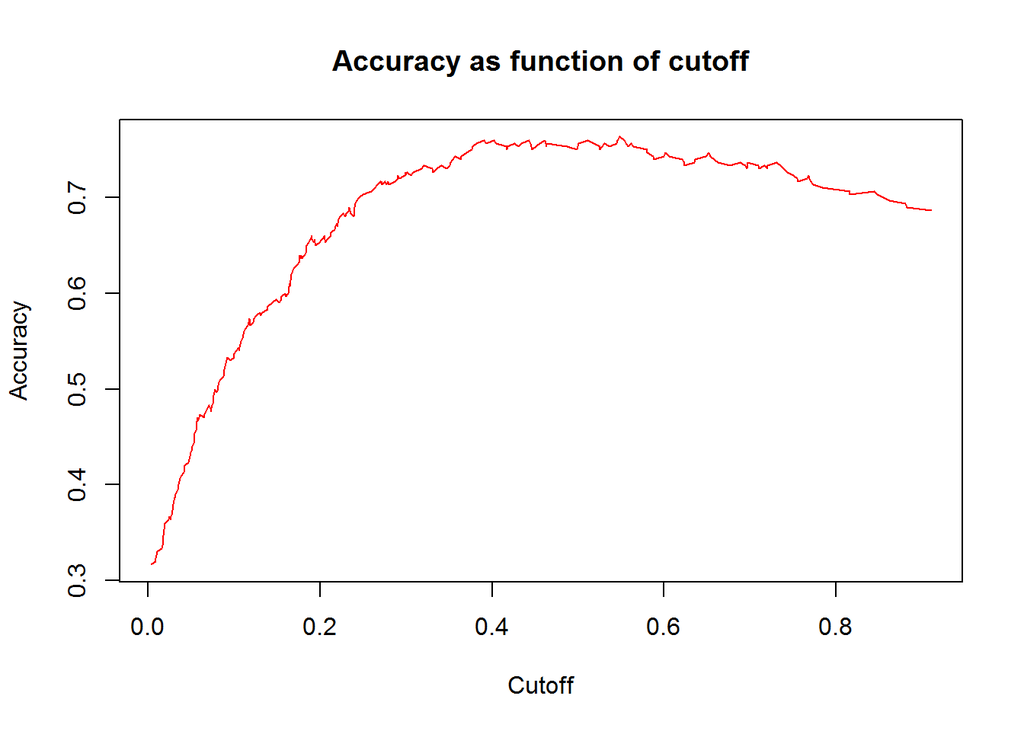

```
## Confusion Matrix and Statistics
##
##           Reference
## Prediction   0   1
##          0 189  16
##          1  55  40
##
##                Accuracy : 0.7633
##                  95% CI : (0.7111, 0.8103)
##     No Information Rate : 0.8133
##     P-Value [Acc > NIR] : 0.9874
##
##                   Kappa : 0.3855
##  Mcnemar's Test P-Value : 6.49e-06
##
##             Sensitivity : 0.7746
##             Specificity : 0.7143
##          Pos Pred Value : 0.9220
##          Neg Pred Value : 0.4211
##              Prevalence : 0.8133
##          Detection Rate : 0.6300
##    Detection Prevalence : 0.6833
##       Balanced Accuracy : 0.7444
##
##        'Positive' Class : 0
##
```

Poniżej zawarty jest wykres ROC.

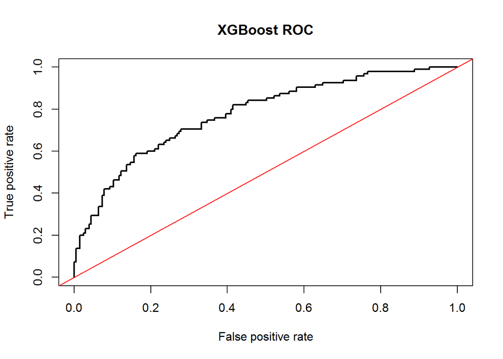

Na zbiorze testowym udało nam się otrzymać współczynnik Giniego wynoszący 0.56 oraz statystykę KS 0.43

### Wnioski

W powyższej pracy porównaliśmy pod kątem Credit Scoringu dwa modele - regresję logistyczną oraz XGBoost. Na wspólnej próbie testowej otrzymaliśmy bardzo podobne wartości Accuracy oraz Gini. Na tej podstawie nie można jednoznacznie stwierdzić, że jeden model jest lepszy od drugiego. Spodziewaliśmy się znacznej przewagi XGBoost, ponieważ jest to algorytm z reguły dobrze dopasowujący się do trudnych obserwacji oraz dopuszczający nietrywialne interakcje. Oba modele niesłusznie odrzuciły dość dużą ilość aplikacji. Problemem może być dość mała wielkość próbki - zaledwie 1000 obserwacji, co pociąga za sobą specyficzny charakter danych. W celu usprawnienia działania klasyfikacji proponujemy poszukanie modelu, który maksymalizowałby swoistość i być może stworzenie stackowanego algorytmu. Pomocne może być także grupowanie i segmentacja problematycznych klientów w celu odnalezienia nietrywialnych wzorców.